# Biostat 203B Homework 5

Due Mar 22 @ 11:59PM

Author

Chun-Siang Huang and 205111921

## Predicting ICU duration

Using the ICU cohort `mimiciv_icu_cohort.rds` you built in Homework 4, develop at least three machine learning approaches (logistic regression with enet regularization, random forest, boosting, SVM, MLP, etc) plus a model stacking approach for predicting whether a patient’s ICU stay will be longer than 2 days. You should use the `los_long` variable as the outcome. You algorithms can use patient demographic information (gender, age at ICU `intime`, marital status, race), ICU admission information (first care unit), the last lab measurements before the ICU stay, and first vital measurements during ICU stay as features. You are welcome to use any feature engineering techniques you think are appropriate; but make sure to not use features that are not available at an ICU stay’s `intime`. For instance, `last_careunit` cannot be used in your algorithms.

1. Data preprocessing and feature engineering.
2. Partition data into 50% training set and 50% test set. Stratify partitioning according to `los_long`. For grading purpose, sort the data by `subject_id`, `hadm_id`, and `stay_id` and use the seed `203` for the initial data split. Below is the sample code.

```r
# Load libraries
library(GGally)
library(gtsummary)
library(ranger)
library(tidyverse)
library(tidymodels)
library(xgboost)
library(doParallel)
library(stacks)
library(keras)
```

```r
# Load data
mimic_icu_cohort <- readRDS("mimic_icu_cohort.rds")

# sort
mimic_icu_cohort <- mimic_icu_cohort |>
  arrange(subject_id, hadm_id, stay_id) |>
  mutate(admit_hour = hour(admittime),
         intime_hour = hour(intime),
         admit_hour = as.factor(admit_hour),
         intime_hour = as.factor(intime_hour)) |>
  select(-subject_id,
         -hadm_id,
         -stay_id,
         -intime,
         -outtime,
         -admittime,
         -dischtime,
         -deathtime,
         -admit_provider_id,
         -los,
         -discharge_location,
         -edregtime,
         -edouttime,
         -hospital_expire_flag,
         -anchor_age,
         -anchor_year,
         -anchor_year_group,
         -dod,
         -last_careunit)

mimic_icu_cohort |>
  print(width = Inf)
```

```
# A tibble: 73,181 × 25
   first_careunit                                   admission_type
   <fct>                                            <fct>
 1 Medical Intensive Care Unit (MICU)               EW EMER.
 2 Medical Intensive Care Unit (MICU)               EW EMER.
 3 Surgical Intensive Care Unit (SICU)              EW EMER.
 4 Surgical Intensive Care Unit (SICU)              Other
 5 Medical/Surgical Intensive Care Unit (MICU/SICU) EW EMER.
 6 Medical Intensive Care Unit (MICU)               OBSERVATION ADMIT
 7 Cardiac Vascular Intensive Care Unit (CVICU)     SURGICAL SAME DAY ADMISSION
 8 Medical Intensive Care Unit (MICU)               EW EMER.
 9 Other                                            EW EMER.
10 Medical/Surgical Intensive Care Unit (MICU/SICU) EW EMER.
   admission_location insurance language marital_status race  gender age_intime
   <fct>              <chr>     <chr>    <chr>          <chr> <chr>       <int>
```

[output cut: 59 more lines]

```r
mimic_icu_cohort |>
  tbl_summary(by = los_long)
```

| **Characteristic** | **FALSE**, N = 38,050<sup>1</sup> | **TRUE**, N = 35,131<sup>1</sup> |
| --- | --- | --- |
| first_careunit |  |  |
| Cardiac Vascular Intensive Care Unit (CVICU) | 5,827 (15%) | 5,755 (16%) |
| Medical Intensive Care Unit (MICU) | 8,782 (23%) | 7,116 (20%) |
| Medical/Surgical Intensive Care Unit (MICU/SICU) | 7,147 (19%) | 5,586 (16%) |
| Surgical Intensive Care Unit (SICU) | 5,654 (15%) | 5,507 (16%) |
| Trauma SICU (TSICU) | 4,464 (12%) | 4,228 (12%) |
| Other | 6,176 (16%) | 6,939 (20%) |
| admission_type |  |  |
| EW EMER. | 20,735 (54%) | 17,937 (51%) |
| OBSERVATION ADMIT | 4,329 (11%) | 4,645 (13%) |
| SURGICAL SAME DAY ADMISSION | 4,340 (11%) | 3,033 (8.6%) |
| URGENT | 5,494 (14%) | 6,959 (20%) |
| Other | 3,152 (8.3%) | 2,557 (7.3%) |
| admission_location |  |  |
| EMERGENCY ROOM | 19,602 (52%) | 16,279 (46%) |
| PHYSICIAN REFERRAL | 8,986 (24%) | 7,412 (21%) |
| TRANSFER FROM HOSPITAL | 6,839 (18%) | 8,959 (26%) |
| Other | 2,623 (6.9%) | 2,481 (7.1%) |
| insurance |  |  |
| Medicaid | 3,060 (8.0%) | 2,468 (7.0%) |
| Medicare | 16,489 (43%) | 16,602 (47%) |
| Other | 18,501 (49%) | 16,061 (46%) |
| language |  |  |
| ? | 3,692 (9.7%) | 3,751 (11%) |
| ENGLISH | 34,358 (90%) | 31,380 (89%) |
| marital_status |  |  |
| DIVORCED | 2,843 (8.0%) | 2,561 (7.9%) |
| MARRIED | 16,984 (48%) | 15,784 (49%) |
| SINGLE | 11,175 (31%) | 9,683 (30%) |
| WIDOWED | 4,699 (13%) | 4,339 (13%) |

[output cut: 87 more lines]

<sup>1</sup> n (%); Median (IQR)

```r
# Initial split into test and non-test sets
data_split <- initial_split(
  mimic_icu_cohort,
  # stratify by los_long
  strata = "los_long",
  prop = 0.5
  )
data_split
```

```
<Training/Testing/Total>
<36590/36591/73181>
```

```r
data_train <- training(data_split)
dim(data_train)
```

```
[1] 36590    25
```

```r
data_test <- testing(data_split)
dim(data_test)
```

```
[1] 36591    25
```

```r
set.seed(203)

folds <- vfold_cv(data_train, v = 5)
folds
```

```
#  5-fold cross-validation
# A tibble: 5 × 2
  splits               id
  <list>               <chr>
1 <split [29272/7318]> Fold1
2 <split [29272/7318]> Fold2
3 <split [29272/7318]> Fold3
4 <split [29272/7318]> Fold4
5 <split [29272/7318]> Fold5
```

3. Train and tune the models using the training set.

```r
#Recipe
data_recipe <- recipe(los_long ~ ., data = data_train) |>
  step_impute_mean(all_numeric_predictors()) |>
  step_impute_mode(all_nominal_predictors()) |>
  step_dummy(all_nominal_predictors()) |>
  step_zv(all_numeric_predictors()) |>
  step_normalize(all_numeric_predictors())
```

### Logistic regression with enet regularization

```r
#Model
logit_mod <-
  logistic_reg(
    penalty = tune(),
    mixture = tune()
  ) |>
  set_engine("glmnet", standardize = FALSE) |>
  print()
```

```
Logistic Regression Model Specification (classification)

Main Arguments:
  penalty = tune()
  mixture = tune()

Engine-Specific Arguments:
  standardize = FALSE

Computational engine: glmnet
```

```r
#Workflow
logit_wf <-
  workflow() |>
  add_recipe(data_recipe) |>
  add_model(logit_mod) |>
  print()
```

```
══ Workflow ════════════════════════════════════════════════════════════════════
Preprocessor: Recipe
Model: logistic_reg()

── Preprocessor ────────────────────────────────────────────────────────────────
5 Recipe Steps

• step_impute_mean()
• step_impute_mode()
• step_dummy()
• step_zv()
• step_normalize()

── Model ───────────────────────────────────────────────────────────────────────
Logistic Regression Model Specification (classification)

Main Arguments:
  penalty = tune()
  mixture = tune()

Engine-Specific Arguments:
  standardize = FALSE

Computational engine: glmnet
```

```r
#Tuning
logit_grid <- grid_regular(
  penalty(range = c(-5, 2)),
  mixture(),
  levels = c(25, 4)
)
```

```r
# eval set to F to avoid long runtime and large file, to render fully set eval = T
#Cross validation
(logit_fit <- logit_wf |>
  tune_grid(
    resamples = folds,
    grid = logit_grid,
    metrics = metric_set(roc_auc, accuracy),
    control = control_stack_grid()
    )) |>
  system.time()
logit_fit

logit_fit |> write_rds("./logit_fit.rds")
```

```
# A tibble: 200 × 8
     penalty mixture .metric  .estimator  mean     n std_err
       <dbl>   <dbl> <chr>    <chr>      <dbl> <int>   <dbl>
 1 0.00001         0 accuracy binary     0.586     5 0.00378
 2 0.00001         0 roc_auc  binary     0.618     5 0.00388
 3 0.0000196       0 accuracy binary     0.586     5 0.00378
 4 0.0000196       0 roc_auc  binary     0.618     5 0.00388
 5 0.0000383       0 accuracy binary     0.586     5 0.00378
 6 0.0000383       0 roc_auc  binary     0.618     5 0.00388
 7 0.0000750       0 accuracy binary     0.586     5 0.00378
 8 0.0000750       0 roc_auc  binary     0.618     5 0.00388
 9 0.000147        0 accuracy binary     0.586     5 0.00378
10 0.000147        0 roc_auc  binary     0.618     5 0.00388
   .config
   <chr>
 1 Preprocessor1_Model001
 2 Preprocessor1_Model001
 3 Preprocessor1_Model002
 4 Preprocessor1_Model002
 5 Preprocessor1_Model003
 6 Preprocessor1_Model003
 7 Preprocessor1_Model004
 8 Preprocessor1_Model004
 9 Preprocessor1_Model005
10 Preprocessor1_Model005
# ℹ 190 more rows
```

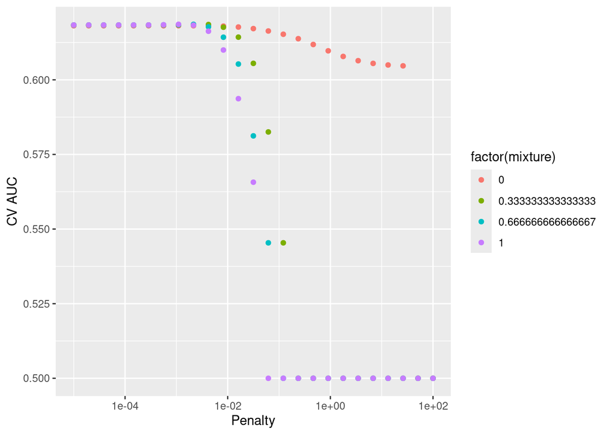

```r
logit_fit <- readRDS("./logit_fit.rds")

logit_fit |>
  # aggregate metrics from K folds
  collect_metrics() |>
  print(width = Inf) |>
  filter(.metric == "roc_auc") |>
  ggplot(mapping =
           aes(x = penalty,
               y = mean,
               color = factor(mixture))) +
  geom_point() +
  labs(x = "Penalty", y = "CV AUC") +
  scale_x_log10()
```

```r
logit_fit |>
  show_best("roc_auc")
```

```
# A tibble: 5 × 8
   penalty mixture .metric .estimator  mean     n std_err .config
     <dbl>   <dbl> <chr>   <chr>      <dbl> <int>   <dbl> <chr>
1 0.00110    1     roc_auc binary     0.619     5 0.00391 Preprocessor1_Model083
2 0.00215    0.667 roc_auc binary     0.619     5 0.00398 Preprocessor1_Model059
3 0.00422    0.333 roc_auc binary     0.619     5 0.00399 Preprocessor1_Model035
4 0.00110    0.667 roc_auc binary     0.618     5 0.00387 Preprocessor1_Model058
5 0.000562   1     roc_auc binary     0.618     5 0.00385 Preprocessor1_Model082
```

```r
best_logit <- logit_fit |>
  select_best("roc_auc")
best_logit
```

```
# A tibble: 1 × 3
  penalty mixture .config
    <dbl>   <dbl> <chr>
1 0.00110       1 Preprocessor1_Model083
```

```r
#Testing
# Final workflow
final_logit_wf <- logit_wf |>
  finalize_workflow(best_logit)
final_logit_wf
```

```
══ Workflow ════════════════════════════════════════════════════════════════════
Preprocessor: Recipe
Model: logistic_reg()

── Preprocessor ────────────────────────────────────────────────────────────────
5 Recipe Steps

• step_impute_mean()
• step_impute_mode()
• step_dummy()
• step_zv()
• step_normalize()

── Model ───────────────────────────────────────────────────────────────────────
Logistic Regression Model Specification (classification)

Main Arguments:
  penalty = 0.00110069417125221
  mixture = 1

Engine-Specific Arguments:
  standardize = FALSE

Computational engine: glmnet
```

```r
# Fit the whole training set, then predict the test cases
set.seed(203)
final_logit_fit <-
  final_logit_wf |>
  last_fit(data_split)
final_logit_fit
```

```
# Resampling results
# Manual resampling
# A tibble: 1 × 6
  splits                id             .metrics .notes   .predictions .workflow
  <list>                <chr>          <list>   <list>   <list>       <list>
1 <split [36590/36591]> train/test sp… <tibble> <tibble> <tibble>     <workflow>
```

```r
final_logit_fit |>
  collect_metrics()
```

```
# A tibble: 2 × 4
  .metric  .estimator .estimate .config
  <chr>    <chr>          <dbl> <chr>
1 accuracy binary         0.585 Preprocessor1_Model1
2 roc_auc  binary         0.618 Preprocessor1_Model1
```

### Boosting

```r
# Model
boost_mod <-
  boost_tree(
    mode = "classification",
    trees = 1000,
    tree_depth = tune(),
    learn_rate = tune()
  ) |>
  set_engine("xgboost")
boost_mod
```

```
Boosted Tree Model Specification (classification)

Main Arguments:
  trees = 1000
  tree_depth = tune()
  learn_rate = tune()

Computational engine: xgboost
```

```r
# Workflow
boost_wf <-
  workflow() |>
  add_recipe(data_recipe) |>
  add_model(boost_mod)

# Tuning
boost_grid <- grid_regular(
  tree_depth(range = c(1L, 3L)),
  learn_rate(range = c(-5, 2), trans = log10_trans()),
  levels = c(3, 5)
  )
```

```r
# eval set to F to avoid long runtime and large file, to render fully set eval = T
library(doParallel)
registerDoParallel(cores = 4)
# Cross validation
set.seed(203)

boost_fit <- boost_wf |>
  tune_grid(
    resamples = folds,
    grid = boost_grid,
    metrics = metric_set(roc_auc, accuracy),
    control = control_stack_grid()
  )

boost_fit |> write_rds("./boost_fit.rds")

stopImplicitCluster()
registerDoSEQ()
```

```
# A tibble: 30 × 8
   tree_depth learn_rate .metric  .estimator  mean     n std_err
        <int>      <dbl> <chr>    <chr>      <dbl> <int>   <dbl>
 1          1   0.00001  accuracy binary     0.549     5 0.00319
 2          1   0.00001  roc_auc  binary     0.538     5 0.00253
 3          2   0.00001  accuracy binary     0.548     5 0.00153
 4          2   0.00001  roc_auc  binary     0.553     5 0.00215
 5          3   0.00001  accuracy binary     0.554     5 0.00143
 6          3   0.00001  roc_auc  binary     0.564     5 0.00136
 7          1   0.000562 accuracy binary     0.550     5 0.00333
 8          1   0.000562 roc_auc  binary     0.575     5 0.00231
 9          2   0.000562 accuracy binary     0.557     5 0.00209
10          2   0.000562 roc_auc  binary     0.586     5 0.00284
   .config
   <chr>
 1 Preprocessor1_Model01
 2 Preprocessor1_Model01
 3 Preprocessor1_Model02
 4 Preprocessor1_Model02
 5 Preprocessor1_Model03
 6 Preprocessor1_Model03
 7 Preprocessor1_Model04
 8 Preprocessor1_Model04
 9 Preprocessor1_Model05
10 Preprocessor1_Model05
# ℹ 20 more rows
```

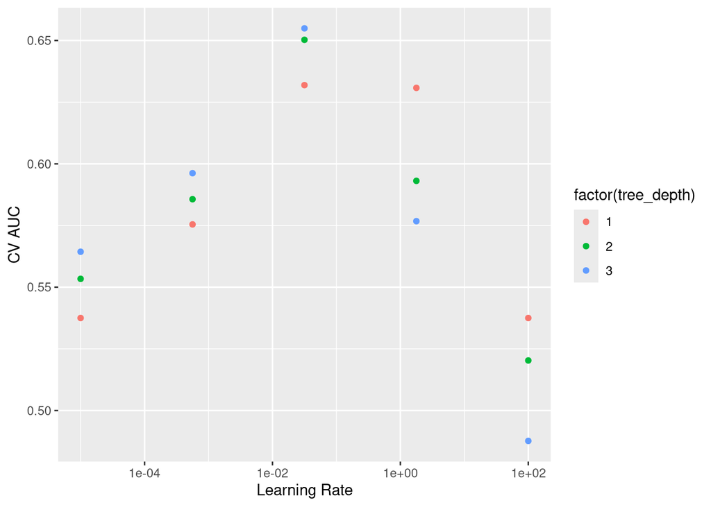

```r
boost_fit <- readRDS("./boost_fit.rds")

boost_fit |>
  collect_metrics() |>
  print(width = Inf) |>
  filter(.metric == "roc_auc") |>
  ggplot(mapping =
           aes(x = learn_rate,
               y = mean,
               color = factor(tree_depth))) +
  geom_point() +
  labs(x = "Learning Rate", y = "CV AUC") +
  scale_x_log10()
```

```r
boost_fit |>
  show_best("roc_auc")
```

```
# A tibble: 5 × 8
  tree_depth learn_rate .metric .estimator  mean     n std_err .config
       <int>      <dbl> <chr>   <chr>      <dbl> <int>   <dbl> <chr>
1          3   0.0316   roc_auc binary     0.655     5 0.00474 Preprocessor1_Mo…
2          2   0.0316   roc_auc binary     0.650     5 0.00418 Preprocessor1_Mo…
3          1   0.0316   roc_auc binary     0.632     5 0.00411 Preprocessor1_Mo…
4          1   1.78     roc_auc binary     0.631     5 0.00410 Preprocessor1_Mo…
5          3   0.000562 roc_auc binary     0.596     5 0.00384 Preprocessor1_Mo…
```

```r
best_boost <- boost_fit |>
  select_best("roc_auc")
best_boost
```

```
# A tibble: 1 × 3
  tree_depth learn_rate .config
       <int>      <dbl> <chr>
1          3     0.0316 Preprocessor1_Model09
```

```r
# Testing
# Final workflow
final_boost_wf <- boost_wf |>
  finalize_workflow(best_boost)
final_boost_wf
```

```
══ Workflow ════════════════════════════════════════════════════════════════════
Preprocessor: Recipe
Model: boost_tree()

── Preprocessor ────────────────────────────────────────────────────────────────
5 Recipe Steps

• step_impute_mean()
• step_impute_mode()
• step_dummy()
• step_zv()
• step_normalize()

── Model ───────────────────────────────────────────────────────────────────────
Boosted Tree Model Specification (classification)

Main Arguments:
  trees = 1000
  tree_depth = 3
  learn_rate = 0.0316227766016838

Computational engine: xgboost
```

```r
# Fit the whole training set, then predict the test cases
set.seed(203)
final_boost_fit <-
  final_boost_wf |>
  last_fit(data_split)

final_boost_fit |>
  collect_metrics()
```

```
# A tibble: 2 × 4
  .metric  .estimator .estimate .config
  <chr>    <chr>          <dbl> <chr>
1 accuracy binary         0.616 Preprocessor1_Model1
2 roc_auc  binary         0.659 Preprocessor1_Model1
```

### MLP model

```r
# Model
mlp_mod <-
  mlp(
    mode = "classification",
    hidden_units = tune(),
    dropout = tune(),
    epochs = 15,
  ) |>
  set_engine("keras", verbose = 0)
mlp_mod
```

```
Single Layer Neural Network Model Specification (classification)

Main Arguments:
  hidden_units = tune()
  dropout = tune()
  epochs = 15

Engine-Specific Arguments:
  verbose = 0

Computational engine: keras
```

```r
# Workflow
mlp_wf <-
  workflow() |>
  add_recipe(data_recipe) |>
  add_model(mlp_mod)
mlp_wf
```

```
══ Workflow ════════════════════════════════════════════════════════════════════
Preprocessor: Recipe
Model: mlp()

── Preprocessor ────────────────────────────────────────────────────────────────
5 Recipe Steps

• step_impute_mean()
• step_impute_mode()
• step_dummy()
• step_zv()
• step_normalize()

── Model ───────────────────────────────────────────────────────────────────────
Single Layer Neural Network Model Specification (classification)

Main Arguments:
  hidden_units = tune()
  dropout = tune()
  epochs = 15

Engine-Specific Arguments:
  verbose = 0

Computational engine: keras
```

```r
# Tuning
mlp_grid <- grid_regular(
  hidden_units(range = c(1, 10)),
  dropout(range = c(0, 0.2)),
  levels = c(3,3)
  )
```

```r
# eval set to F to avoid long runtime and large file, to render fully set eval = T
# Cross validation
set.seed(203)

mlp_fit <- mlp_wf |>
  tune_grid(
    resamples = folds,
    grid = mlp_grid,
    metrics = metric_set(roc_auc, accuracy),
    control = control_stack_grid()
  )

mlp_fit |> write_rds("./mlp_fit.rds")
```

```
# A tibble: 18 × 8
   hidden_units dropout .metric  .estimator  mean     n  std_err
          <int>   <dbl> <chr>    <chr>      <dbl> <int>    <dbl>
 1            1     0   accuracy binary     0.520     5 0.00456
 2            1     0   roc_auc  binary     0.500     5 0.000318
 3            5     0   accuracy binary     0.592     5 0.00261
 4            5     0   roc_auc  binary     0.626     5 0.00347
 5           10     0   accuracy binary     0.590     5 0.00203
 6           10     0   roc_auc  binary     0.625     5 0.00233
 7            1     0.1 accuracy binary     0.520     5 0.00456
 8            1     0.1 roc_auc  binary     0.500     5 0.000172
 9            5     0.1 accuracy binary     0.592     5 0.00184
10            5     0.1 roc_auc  binary     0.627     5 0.00347
11           10     0.1 accuracy binary     0.590     5 0.00237
12           10     0.1 roc_auc  binary     0.622     5 0.00301
```

[output cut: 26 more lines]

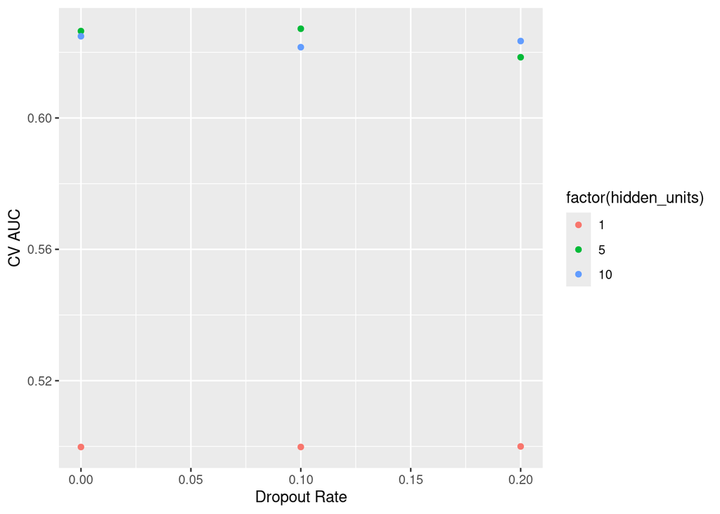

```r
mlp_fit <- readRDS("./mlp_fit.rds")

mlp_fit |>
  collect_metrics() |>
  print(width = Inf) |>
  filter(.metric == "roc_auc") |>
  ggplot(mapping =
           aes(x = dropout,
               y = mean,
               color = factor(hidden_units))) +
  geom_point() +
  labs(x = "Dropout Rate", y = "CV AUC")
```

```r
mlp_fit |>
  show_best("roc_auc")
```

```
# A tibble: 5 × 8
  hidden_units dropout .metric .estimator  mean     n std_err .config
         <int>   <dbl> <chr>   <chr>      <dbl> <int>   <dbl> <chr>
1            5     0.1 roc_auc binary     0.627     5 0.00347 Preprocessor1_Mod…
2            5     0   roc_auc binary     0.626     5 0.00347 Preprocessor1_Mod…
3           10     0   roc_auc binary     0.625     5 0.00233 Preprocessor1_Mod…
4           10     0.2 roc_auc binary     0.623     5 0.00463 Preprocessor1_Mod…
5           10     0.1 roc_auc binary     0.622     5 0.00301 Preprocessor1_Mod…
```

```r
best_mlp <- mlp_fit |>
  select_best("roc_auc")
best_mlp
```

```
# A tibble: 1 × 3
  hidden_units dropout .config
         <int>   <dbl> <chr>
1            5     0.1 Preprocessor1_Model5
```

```r
# Testing
# Final workflow
final_mlp_wf <- mlp_wf |>
  finalize_workflow(best_mlp)

# Fit the whole training set, then predict the test cases
final_mlp_fit <-
  final_mlp_wf |>
  last_fit(data_split)
```

```
1144/1144 - 2s - 2s/epoch - 1ms/step
1144/1144 - 2s - 2s/epoch - 1ms/step
```

```r
final_mlp_fit |>
  collect_metrics()
```

```
# A tibble: 2 × 4
  .metric  .estimator .estimate .config
  <chr>    <chr>          <dbl> <chr>
1 accuracy binary         0.593 Preprocessor1_Model1
2 roc_auc  binary         0.627 Preprocessor1_Model1
```

### Model stacking

```r
# Model
stack_mod <-
  stacks() |>
  add_candidates(logit_fit) |>
  add_candidates(boost_fit) |>
  add_candidates(mlp_fit) |>
  blend_predictions(
    penalty = 10^(-5:-1),
    metrics = c("roc_auc")
    ) |>
  fit_members()
```

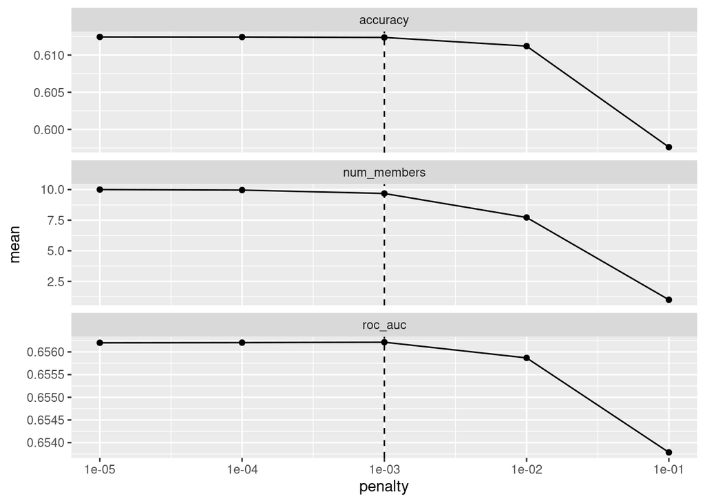

```r
# Visualize
autoplot(stack_mod)
```

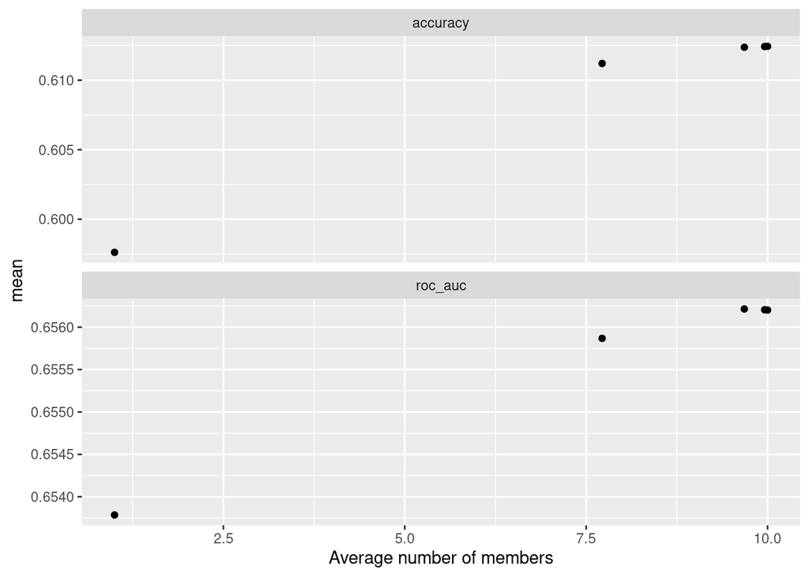

```r
autoplot(stack_mod, type = "members")
```

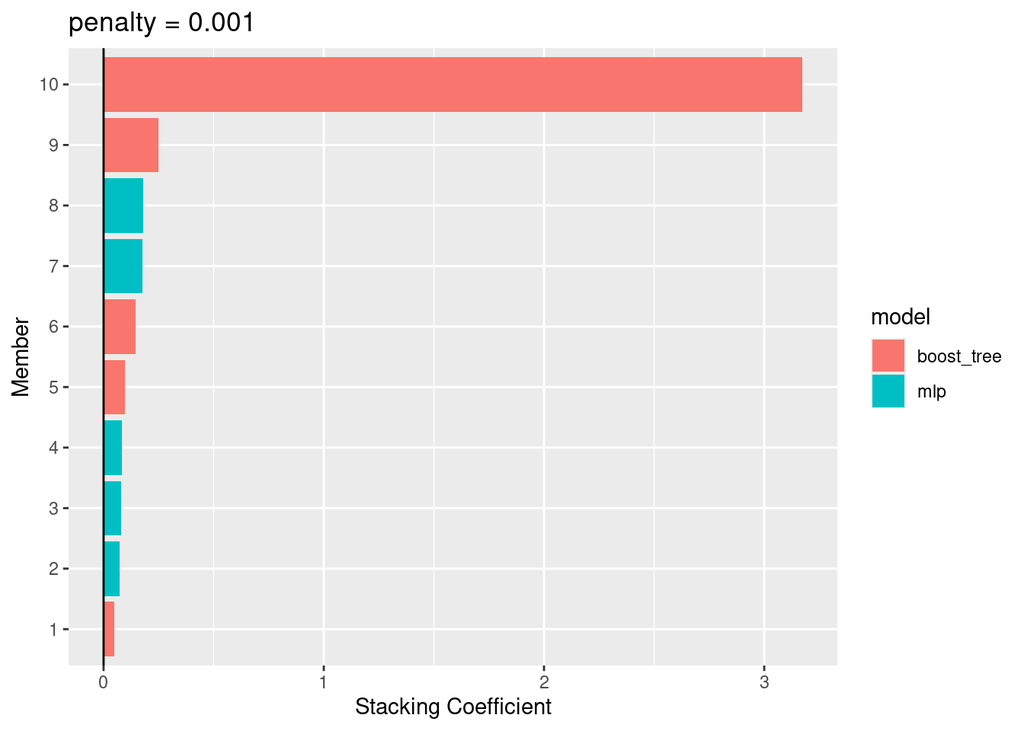

```r
autoplot(stack_mod, type = "weights")
```

```r
# Collect parameters
collect_parameters(stack_mod, "logit_fit")
```

```
# A tibble: 42 × 5
   member          penalty mixture terms                       coef
   <chr>             <dbl>   <dbl> <chr>                      <dbl>
 1 logit_fit_1_001 0.00001       0 .pred_TRUE_logit_fit_1_001     0
 2 logit_fit_1_011 0.00825       0 .pred_TRUE_logit_fit_1_011     0
 3 logit_fit_1_012 0.0162        0 .pred_TRUE_logit_fit_1_012     0
 4 logit_fit_1_013 0.0316        0 .pred_TRUE_logit_fit_1_013     0
 5 logit_fit_1_014 0.0619        0 .pred_TRUE_logit_fit_1_014     0
 6 logit_fit_1_015 0.121         0 .pred_TRUE_logit_fit_1_015     0
 7 logit_fit_1_016 0.237         0 .pred_TRUE_logit_fit_1_016     0
 8 logit_fit_1_017 0.464         0 .pred_TRUE_logit_fit_1_017     0
 9 logit_fit_1_018 0.909         0 .pred_TRUE_logit_fit_1_018     0
10 logit_fit_1_019 1.78          0 .pred_TRUE_logit_fit_1_019     0
# ℹ 32 more rows
```

```r
collect_parameters(stack_mod, "boost_fit")
```

```
# A tibble: 15 × 5
   member         tree_depth learn_rate terms                       coef
   <chr>               <int>      <dbl> <chr>                      <dbl>
 1 boost_fit_1_01          1   0.00001  .pred_TRUE_boost_fit_1_01 0
 2 boost_fit_1_02          2   0.00001  .pred_TRUE_boost_fit_1_02 0
 3 boost_fit_1_03          3   0.00001  .pred_TRUE_boost_fit_1_03 0
 4 boost_fit_1_04          1   0.000562 .pred_TRUE_boost_fit_1_04 0
 5 boost_fit_1_05          2   0.000562 .pred_TRUE_boost_fit_1_05 0
 6 boost_fit_1_06          3   0.000562 .pred_TRUE_boost_fit_1_06 0
 7 boost_fit_1_07          1   0.0316   .pred_TRUE_boost_fit_1_07 0
 8 boost_fit_1_08          2   0.0316   .pred_TRUE_boost_fit_1_08 0
 9 boost_fit_1_09          3   0.0316   .pred_TRUE_boost_fit_1_09 3.17
10 boost_fit_1_10          1   1.78     .pred_TRUE_boost_fit_1_10 0.248
11 boost_fit_1_11          2   1.78     .pred_TRUE_boost_fit_1_11 0.144
12 boost_fit_1_12          3   1.78     .pred_TRUE_boost_fit_1_12 0.0981
13 boost_fit_1_13          1 100        .pred_TRUE_boost_fit_1_13 0
14 boost_fit_1_14          2 100        .pred_TRUE_boost_fit_1_14 0
15 boost_fit_1_15          3 100        .pred_TRUE_boost_fit_1_15 0.0495
```

```r
collect_parameters(stack_mod, "mlp_fit")
```

```
# A tibble: 9 × 5
  member      hidden_units dropout terms                    coef
  <chr>              <int>   <dbl> <chr>                   <dbl>
1 mlp_fit_1_1            1     0   .pred_TRUE_mlp_fit_1_1 0
2 mlp_fit_1_2            5     0   .pred_TRUE_mlp_fit_1_2 0.0788
3 mlp_fit_1_3           10     0   .pred_TRUE_mlp_fit_1_3 0.179
4 mlp_fit_1_4            1     0.1 .pred_TRUE_mlp_fit_1_4 0
5 mlp_fit_1_5            5     0.1 .pred_TRUE_mlp_fit_1_5 0.178
6 mlp_fit_1_6           10     0.1 .pred_TRUE_mlp_fit_1_6 0.0732
7 mlp_fit_1_7            1     0.2 .pred_TRUE_mlp_fit_1_7 0
8 mlp_fit_1_8            5     0.2 .pred_TRUE_mlp_fit_1_8 0
9 mlp_fit_1_9           10     0.2 .pred_TRUE_mlp_fit_1_9 0.0824
```

```r
#Final classification
stack_pred <- data_test |>
  bind_cols(
    predict(stack_mod,
            new_data = data_test,
            type = "prob")) |>
  mutate(pred = .pred_FALSE < 0.5) |>
  mutate(pred = as.factor(pred)) |>
  print(width = Inf)
```

```
1144/1144 - 2s - 2s/epoch - 1ms/step
1144/1144 - 2s - 2s/epoch - 2ms/step
1144/1144 - 2s - 2s/epoch - 2ms/step
1144/1144 - 2s - 2s/epoch - 2ms/step
1144/1144 - 2s - 2s/epoch - 2ms/step
# A tibble: 36,591 × 28
   first_careunit                                   admission_type
   <fct>                                            <fct>
 1 Medical Intensive Care Unit (MICU)               EW EMER.
 2 Surgical Intensive Care Unit (SICU)              Other
 3 Cardiac Vascular Intensive Care Unit (CVICU)     SURGICAL SAME DAY ADMISSION
 4 Medical Intensive Care Unit (MICU)               EW EMER.
 5 Other                                            EW EMER.
 6 Medical Intensive Care Unit (MICU)               EW EMER.
 7 Surgical Intensive Care Unit (SICU)              EW EMER.
```

[output cut: 64 more lines]

```r
yardstick::roc_auc(
  stack_pred,
  truth = los_long,
  contains(".pred_FALSE")
  )
```

```
# A tibble: 1 × 3
  .metric .estimator .estimate
  <chr>   <chr>          <dbl>
1 roc_auc binary         0.706
```

```r
yardstick::accuracy(
  stack_pred,
  truth = los_long,
  estimate = pred
  )
```

```
# A tibble: 1 × 3
  .metric  .estimator .estimate
  <chr>    <chr>          <dbl>
1 accuracy binary         0.649
```

## Comparison and interpretation

4. Compare model classification performance on the test set. Report both the area under ROC curve and accuracy for each machine learning algorithm and the model stacking. Interpret the results. What are the most important features in predicting long ICU stays? How do the models compare in terms of performance and interpretability?

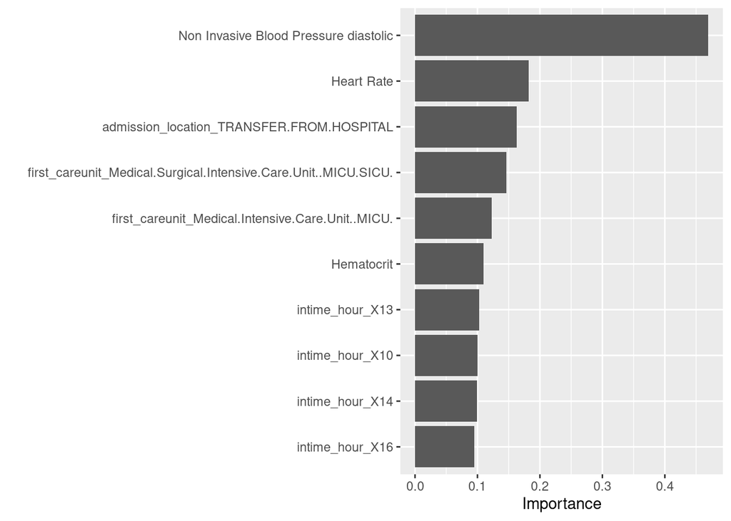

```r
library(vip)
#Importance metric for logistic regression
final_logit <-
  extract_workflow(final_logit_fit)

final_logit |>
  extract_fit_parsnip() %>%
  vip()
```

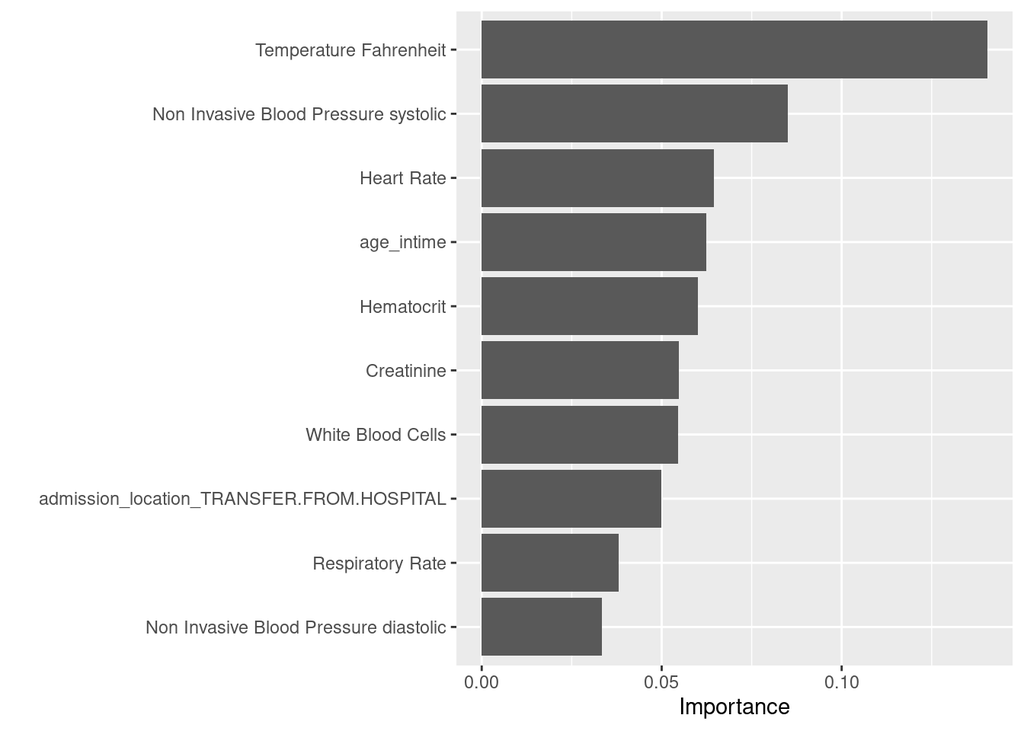

```r
#Importance metric for boosting
final_boost <-
  extract_workflow(final_boost_fit)

final_boost |>
  extract_fit_parsnip() %>%
  vip()
```

Table:

| Method | Accuracy | ROC AUC |
| --- | --- | --- |
| Logistic Regression | 0.585 | 0.618 |
| Boosting | 0.616 | 0.659 |
| MLP | 0.593 | 0.627 |
| Model Stacking | 0.649 | 0.706 |

Out of all the models listed above, the model stacking method has the highest accuracy (0.649) and ROC AUC (0.706), while the logistic regression model has the lowest accuracy and ROC AUC. Although logistic regression has the lowest accuracy and ROC AUC, it is the most interpretable model because we can simply examine the coefficients to understand how each feature affects the outcome. By examining the logistic regression model, we can see that the most important features in predicting long ICU stays are diastolic blood pressure, heart rate, whether admission location was transfer from hospital. Although boosting has lower interpretability due to being a sequential combination of a large number of trees, we can still examine the feature importance. From this we can see that temperature in F, systolic blood pressure, and heart rate were the 3 most important features. Therefore, although MLP, boosting, and model stacking have higher accuracy and ROC AUC, the improved performance comes at a cost of reduced interpretability compared to logistic regression.